# RayTracerR Data Saving Test

# Foreword

This notebook is used for developing the function for saving the data in the appropriate format for Jan’s Parallel Tempered MCMC. Therefore, it mostly goes over the same procedure that is defined in `raytraceR.R`, but saves data after running the simulation.

# Run the simulation

## Prepare the libraries

```r
setwd('/home/geoanton/RayTracerFortran/RayTracer/')
library(dplyr)
library(hexbin)
library(ggplot2)
library(reshape2)
library(pbapply)
library(gridExtra)
# define jet colormap
jet.colors <- colorRampPalette(c("#00007F", "blue", "#007FFF", "cyan", "#7FFF7F", "yellow", "#FF7F00", "red", "#7F0000"))
dyn.load("./subroutineR-quiet.so")
base.name <- 'test_1'
source('~/RayTracerFortran/RayTracer/MiscFunctions.R')
```

## Setup source offsets and depths

From file:

```r
src.df <- read.csv('/home/geoanton/RayTracerFortran/RayTracer/eqdf.csv',header=T)
srcd <- src.df$z
srco <- sqrt(src.df$x**2+src.df$y**2)
NSrc <- length(srcd)
src.to.write <- tibble(offset = srco,depth=srcd)
print(src.to.write)
```

or randomly..:

```r
NSrc <- 5
set.seed(12)
src.df <- tibble(z=runif(NSrc,min=1050,max=4200),x=runif(NSrc,min=10,max=6500),y=runif(NSrc,min=10,max=4500))
srcd <- src.df$z
srco <- sqrt(src.df$x**2+src.df$y**2)
src.to.write <- tibble(offset = srco,depth=srcd)
```

## Setup velocity model

Simple N-layered model here:

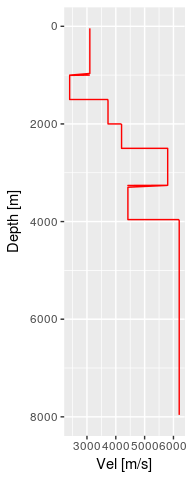

```r
#v <- c(2501,3800,4900,4000,4000)
#d <- c(2000,3000,3500, 4000)   # That's not thicknesses, that's depth to interfaces !
v <- c(3100,2400,3730,4200,5800,4420,6200)
d <- c(1000,1500,2000,2500,3260,3960)   # That's not thicknesses, that's depth to interfaces !
SdRT = 0.016
NLayers <- length(d)
df.vd <- drawProfiles(c(v,0,d),NLayers)
df.vd <- df.vd %>% arrange(d)
true.plot <- ggplot(data = df.vd,aes(x=v,y=d))  + geom_path(col='red')+ labs(x = "Vel [m/s]",y = "Depth [m]")+
                        scale_y_reverse(limits = c(7990,10))

print(true.plot)
```

```r
NLayersMax <- 10
```

## Run forward model and save the times

```r
kd <- 10 # keep rays in rays.dat ???
timeP <- rep(0,NSrc)
timeP <- .Fortran("dff" ,vels=as.numeric(v),depths=as.numeric(d),NLayers=as.integer(NLayers),
                  src_offset=as.numeric(srco),src_depth=as.numeric(srcd),NSrc=as.integer(NSrc),
                  timeP = as.numeric(timeP),keep_delta=as.integer(kd))
print(timeP$timeP)
```

```
[1] 0.7445202 1.3910184 1.5513588 0.8541069 0.6911172
```

and save its results:

```r
# Save the travel times into a one column file:
timeP$timeP <- timeP$timeP + rnorm(NSrc,mean=0,sd=SdRT)
write.table(tibble(t=timeP$timeP),file = sprintf('/home/geoanton/RayTracerFortran/RayTracer/test_1/%s_RT.txt',base.name),sep = ' ',row.names = F,col.names = F)
# Save the source offsets and depths
write.table(src.to.write,file = sprintf('/home/geoanton/RayTracerFortran/RayTracer/test_1/%s_src_data.txt',base.name),sep = ' ',row.names = F,col.names = F)
```

## Setup the parameter.dat file for MCMC

Here we set the parameters of the MCMC simulations instead of manually correcting them :

```r
# NFPMX+1+1
# NFPMX = NPL * NLMX
param.list <- list(NPL = 2, ISMPPRIOR = 0, IEXCHANGE = 0, NDAT_RT = NSrc,
            #       NMODE = 1, NSRC=NSrc,NLMX = NLayers+1, NLMN = NLayers+1, ICHAINTHIN = 5,
                   NMODE = 1, NSRC=NSrc,NLMX = 10, NLMN = 1, ICHAINTHIN = 5,
                   NKEEP=100, NPTCHAINS = 1, dTlog=1.2, lambda = 3.01, hmx = 10000.1, hmn = 100.1,dVs = 0.1, dVpVs=0.1,
                   VpVsmin = 1.5, VpVsmax = 1.8,sdmin = c(0.001,0.001),sdmax = c(0.07,0.07),
                   # MAP below:
                   MAP.k=NLayers+1, MAP.vel = v, MAP.d = c(0,d), MAP.sd = SdRT)
makeParameterFile(param.list = param.list,output.file = '~/RayTracerFortran/RayTracer/test_1/test_1_parameter.dat') ## Create  a parameter file
```

```
the condition has length > 1 and only the first element will be used
```

```r
makeMAPFile(param.list = param.list,output.file = '~/RayTracerFortran/RayTracer/test_1/test_1_map.dat') ## Create  a parameter file
```

```
the condition has length > 1 and only the first element will be usednumber of items to replace is not a multiple of replacement length
```

[output not shown]

## Check the ray results if debugging was switched on

```r
rays.df <- read.rays(nrays=NSrc,timeP = timeP$timeP)
```

```
Read 2 items
Read 2 items
Read 6 items
Read 6 items
Read 7 items
Read 7 items
Read 3 items
Read 3 items
Read 3 items
Read 3 items
```

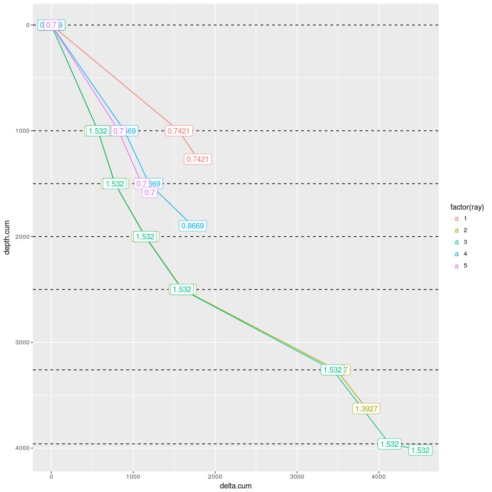

```r
p <- ggplot(data=rays.df,aes(x=delta.cum,y=depth.cum,label = ray.label,col = factor(ray))) + geom_line() + scale_y_reverse()+geom_point()+geom_hline(yintercept = c(0,d),linetype=2)+geom_label()
ggsave(filename = './pngs/ray_example.png',p,width = 7,height = 4)
ggsave(sprintf('/home/geoanton/RayTracerFortran/RayTracer/%s/%s_rays.png',base.name,base.name ),p,width = 12,height=8)
print(p)
```

```r
print(rays.df)
```

| delta | depth | ray | ray.label | depth.cum | delta.cum |
| --- | --- | --- | --- | --- | --- |
| 0.00000 | 0.00000 | 1 | 0.7421 | 0.000 | 0.0000 |
| 1557.51160 | 1000.00000 | 1 | 0.7421 | 1000.000 | 1557.5116 |
| 230.55089 | 268.48688 | 1 | 0.7421 | 1268.487 | 1788.0625 |
| 0.00000 | 0.00000 | 2 | 1.3927 | 0.000 | 0.0000 |
| 570.43653 | 1000.00000 | 2 | 1.3927 | 1000.000 | 570.4365 |
| 207.69118 | 500.00000 | 2 | 1.3927 | 1500.000 | 778.1277 |
| 371.29463 | 500.00000 | 2 | 1.3927 | 2000.000 | 1149.4223 |
| 452.86522 | 500.00000 | 2 | 1.3927 | 2500.000 | 1602.2876 |
| 1879.05160 | 760.00000 | 2 | 1.3927 | 3260.000 | 3481.3392 |
| 365.33535 | 365.99188 | 2 | 1.3927 | 3625.992 | 3846.6745 |

[output cut: 16 more lines]

## Plot the sampling from the voro_sample file

We need to follow the notation given in prmjh_temper.f90 and read in the numbers accordingly : `sample(ikeep,:) = (/ objm(ic)%logL, objm(ic)%logPr, objm(ic)%tcmp, REAL(objm(ic)%k,RP), & ! 4 parameters tmpvoro,objm(ic)%sdparRT,objm(ic)%arpar,objm(ic)%arparRT, & REAL(iaccept,RP)/REAL(iaccept+ireject,RP),REAL(objm(ic)%iaccept_bd,RP),& REAL(objm(ic)%ireject_bd,RP),REAL(objm(ic)%iaccept_bds,RP),REAL(ic,RP),REAL(rank,RP) /)` Here we setup the names of the columns, as well as read the file with the sample table:

```r
col.names <- c('LogL','LogPrior','tcmp','k')
k <- NLayers+1 # by convention of Jan's RJMCMC
NParamPerLayer <- 2
NVoro <- param.list$NLMX*NParamPerLayer
col.names.voro <- rep(NA,NVoro)
# Make Voro Column names - this will be my velocity profiles
vel.names <- paste0(('V'),seq(param.list$NLMX))
depth.names <- paste0(('Z'),seq(param.list$NLMX))
col.names.voro[seq(1,NVoro-1,by=2)] <- depth.names
col.names.voro[seq(2,NVoro,by=2)] <- vel.names
after.voro.names <- c('SdRT','ArPar','ArParRT','acc_ratio','iacc_bd','irej_bd','iacc_bds','ic','rank')
all.names <- c(col.names,col.names.voro,after.voro.names)
var.to.keep <- c(col.names.voro,'SdRT')
# Prepare the true.model:
true.model = tibble(variable =c(vel.names[1:param.list$MAP.k],depth.names[1:param.list$MAP.k],"SdRT"),value = c(v,c(0,d),SdRT))
# Read the chain from the basename_voro_sample.txt
filename <- '~/RayTracerFortran/RayTracer/test_1/test_1_voro_sample.txt'
chain.df <- read.table(filename) %>% tbl_df() %>% mutate(iter = row_number())
colnames(chain.df)[1:length(all.names)] <- all.names
```